# Dimensão VC, classificação online e dimensão de Littlestone

MAC5005 - Fundamentos Matemáticos do Aprendizado Sequencial e Online

Victor S. Portella

IME-USP

2026-03-02

## Relembrando - Aprendizado Estatístico

Conjunto de **atributos** $\cX$ e **rótulos** $\cY$

**Hipótese** $h : \cX \to \cY$ (o que queremos aprender)

**Função de custo** $\ell : \cY^\cX \times (\cX \times \cY) \to \bR$

**Distribuição** $\cD$ **desconhecida**

**Conjunto de treino** $S = ((x_1, y_1), \dotsc, (x_m, y_m))$ gerado **IID** de $\cD$

- Foco em **Classificação binária**: $\cY = \{0, 1\}$ e $\ell(h, (x,y)) = \ones[h(x) \neq y]$
- Erros de **generalização** e de **treino**:
  $$L_{\cD}(h) = \expect_{(x,y) \sim \cD}[\ell(h, (x,y))] \quad\text{e}\quad L_S(h) = \frac{1}{m} \sum_{i=1}^m \ell(h, (x_i, y_i))$$
- **Classe de hipóteses** $\cH \subseteq \cY^{\cX}$
  - **Caso realizável**: Existe $h^* \in \cH$ tal que $h^*(x) = y$ com probabilidade 1 ($L_{\cD}(h^*) = 0$).

## Relembrando - PAC Aprendizado

Uma classe de hipóteses $\cH$ é **Provavelmente Aproximadamente Correto** (PAC) **aprendível agnosticamente** se existe um algoritmo $A \colon (\cX \times \cY)^* \to \cH$ tal que

- Para todo $\eps, \delta$ > 0,
- Existe $M(\eps, \delta) > 0$ tal que
- Para toda distribuição $\cD$ sobre $\cX \times \cY$ realizada por $\cH$,
- Se $m > M(\eps, \delta)$ e $S \sim \cD^m$

então
$$\prob \big( L_{\cD}(A(S)) - \inf_{h \in \cH} L_{\cD}(h) \leq \eps \big) > 1 - \delta$$

## Relembrando - ERM para $\cH$ finito

$$\ERM_\cH(S) \in \argmin_{h \in \cH} L_{S}(h)$$

No caso realizável, se $S \sim \cD^m$, então com probabilidade pelo menos $1 - \delta$
$$L_{\cD}\big(\ERM_\cH(S)\big) \leq \frac{\log |\cH| + \log\frac{1}{\delta}}{m}$$

Seja $S \sim \cD^m$. Então, com probabilidade pelo menos $1 - \delta$
$$L_{\cD}(\ERM_{\cH}(S)) - \inf_{h \in \cH} L_{\cD}(h) \leq \sqrt{\frac{2(\log(|\cH|+1) + \log\frac{1}{\delta})}{m}}$$

# O que acontece quando $\cH$ é infinito?

## O caso de Thresholds

Na lista 1, vimos que a **classe de thresholds** é PAC-aprendível:
$$\cH := \{ \ones[x \geq \tau] \colon \tau \in \bR\} \quad \text{com}~\cX = \bR.$$

Para o caso realizável e $\cH$ de thresholds, se $S \sim \cD^m$, então
$$L_{\cD}(\ERM_{\cH}(S)) \leq \frac{\log\frac{1}{\delta}}{m} \quad \text{com prob.}~\geq 1-\delta$$

No entanto, **nem todo $\cH$ é PAC-aprendível**.

Exemplos: $\cH = \cY^\cX$ ou $\cH = \{x \mapsto \sin(\omega \cdot x): \omega \in \bR\}$

## O que Thresholds tem de especial?

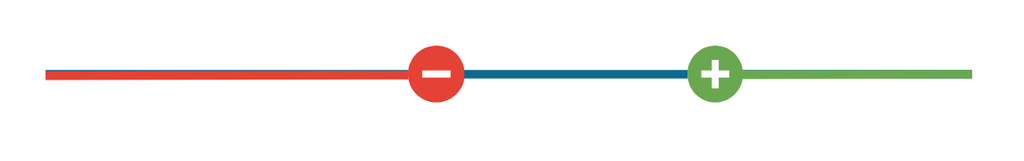

No caso **realizável**:

- Classificação de alguns pontos de $\cX$ já informa a classificação de muitos outros pontos
- Para $\cH = \cY^\cX$, isso não é verdade.
- Como quantificar essa forma de complexidade de $\cH$?

## Função de crescimento (Growth function)

A **função de crescimento** de $\cH$ é dada por
$$\Pi_{\cH}(m) = \max_{x_1, \dotsc, x_m \in \cX} \big|\big\{{(h(x_1), \dotsc, h(x_m))} : h \in \cH\big\}\big|$$

- Para $\cH = \cY^\cX$ e $\cX$ infinito, $\Pi_{\cH}(m) = 2^m$ para todo $m$.
- Para $\cH$ de thresholds, $\Pi_{\cH}(m) = m+1$ para todo $m$

**Intuição**: Mesmo que $|\cH| = \infty$, o que importa é o comportamento no conj. de treino $S$

**Cota da união** em $\cH$ restrito a $S$ ao invés de $\cH$ inteiro.

Eq. 3.23 de [MRT] Com probabilidade pelo menos $1 - \delta$,
$$L_{\cD}(h) - L_{S}(h) \leq \sqrt{ \frac{8(\log(4 \cdot \Pi_{\cH}(2m)) + \log(1/\delta))}{m}} \qquad \forall h \in \cH.$$

## Dimensão VC (Vapnik-Chervonenkis)

O que importa não é o **valor** de $\Pi_{\cH}(m)$, mas sim seu **crescimento**

$\Pi_{\cH}(m) \leq m^d$ para algum $d$ e todo $m$ é suficiente para PAC-aprendizado

$\Pi_{\cH}(m)$ pode ser difícil de calcular

A dimensão VC de $\cH$ é dado por
$$\VC(\cH) := \sup \{m \in \bN \colon \Pi_{\cH}(m) = 2^m\}$$

Note que $\VC(\cH) = d$ se e somente se:

- **Existe** $S = (x_1, \dotsc, x_d) \in \cX^d$ tal que $\cH$ **fragmenta** $S$, isto é
  $$\{(h(x_1), \dotsc, h(x_d)) \; \colon \; h \in \cH\} = \{0,1\}^d$$
- **Para todo** $\hat S \in \cX^{d+1}$, temos que $\cH$ **não fragmenta** $\hat S$

## Exemplo - Thresholds

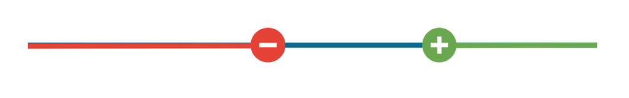

## Exemplo - Hiperplanos

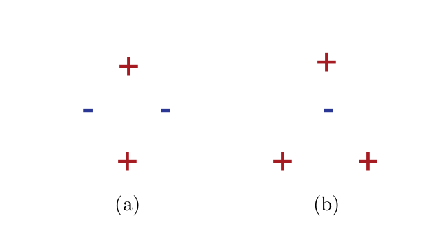

Fig. 3.2 de [MRT]

## Conectando Dimensão VC e $\Pi_{\cH}(m)$

**Pergunta:** Podemos controlar a **função de crescimento** em termos da **dimensão VC**?

- Se $m \leq \VC(\cH)$, então $\Pi_\cH(m) = 2^m$, não é interessante.
- E se $m > \VC(\cH)$?

Lema de Sauer Se $\cH \subseteq {\{0,1\}}^\cX$, então para todo $m \geq 0$
$$\Pi_{\cH}(m)
\leq \sum_{i = 0}^{\VC(\cH)} \binom{m}{i}.$$
Em particular, se $m \geq \VC(\cH)$,
$$\Pi_{\cH}(m)
\leq \Big(\frac{e m }{\VC(\cH)}\Big)^{\VC(\cH)}.$$

## Generalização em termos da Dimensão VC

O Lema de Sauer junto da generalização usando $\Pi_{\cH}(m)$ nos levam à seguinte garantia:

Se $m \geq \VC(\cH)$, com probabilidade pelo menos $1 - \delta$,
$$L_{\cD}(h) - L_{S}(h) \leq \sqrt{\frac{8}{m}} \cdot \sqrt{ \VC(\cH) \log(4 e m) + \log(1/\delta)} \qquad \forall h \in \cH.$$

Em particular, $\cH$ é PAC-aprendível se $|\VC(\cH)| < \infty$.

Além disso, temos a seguinte impossibilidade.

Se $\VC(\cH) = \infty$, então $\cH$ não é PAC-aprendível.

## Extra - Além de ERM e Dimensão VC

Diversos tópicos fundamentais em generalização que estamos pulando:

- Complexidade de Radamacher (depende da **distribuição**)
- Estabilidade algorítmica (depende do **algoritmo**)
- Generalização **além de classificação binária** (regressão, classificação multiclasse, etc)

Ainda é um tópico com pesquisa interessante

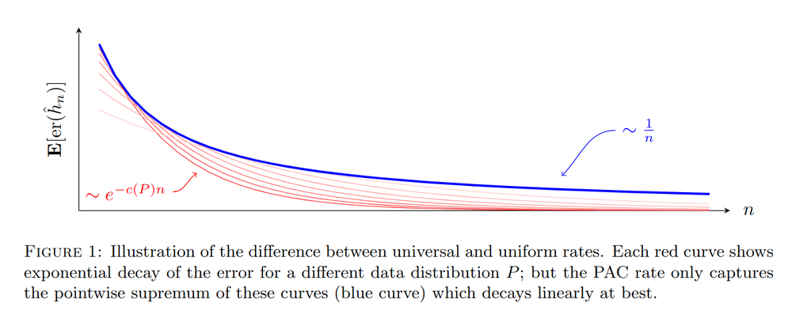

“A Theory of Universal Learning”, Bousquet, Hanneke, Moran, van Handel, Yehudayoff

# Classificação Binária Online

## Classificação Binária Online

Para cada rodada $t = 1, \dotsc, T$:

- O **Adversário** escolhe um $x_t \in \cX$
- O **Jogador/Algoritmo** escolhe uma predição $p_t \in \cY = \{0,1\}$
- O **Adversário** escolhe e revela o rótulo real $y_t \in \{0,1\}$

Assim como no aprendizado estatístico, vamos começar pelo **caso realizável**:

Temos uma classe de hipóteses $\cH \subseteq \cY^\cX$ conhecida, e existe $h^* \in \cH$ tal que
$$y_t = h^*(x_t) \quad \text{para todo}~t \in [T] := \{1, \dotsc, T\}.$$

**Importante: não assumimos mais nada sobre o adversário**

**Pergunta** Qual o número máximo de erros que o algoritmo pode fazer?

## Um primeiro algoritmo: CONSISTENTE

Vamos primeiro considerar o caso **finito**: $|\cH| < \infty$.

**Ideia**: A cada rodada $t$, o jogador escolhe uma hipótese que concorda com as rodadas anteriores:
$$\cV_t := \{ h \in \cH \;\colon\; h(x_s) = y_s~\text{para todo}~s < t \}$$

Na rodada $t \in [T]$ , O algoritmo **CONSISTENTE**

- Escolhe $h_t \in \cV_t$
- Define $p_t = h_t(x_t)$

Para $p_t$ dado por **CONSISTENTE**,
$$\sum_{t = 1}^T \ones[p_t \neq y_t] \leq |\cH| - 1$$

## O algoritmo HALVING

Podemos fazer algo **muito melhor** que **CONSISTENTE**.

**Ideia**: Predizer de acordo com a **maioria** a cada rodada.

Na rodada $t \in [T]$ , O algoritmo **HALVING**

- Escolhe $p_t \in \{0,1\}$ que maximiza o tamanho do conjunto
  $$\{ h \in \cV_t \colon h(x_t) = p_t\}$$

Para $p_t$ dado por **HALVING**,
$$\sum_{t = 1}^T \ones[p_t \neq y_t] \leq \log_2(|\cH|)$$

## E para $\cH$ infinito?

Nenhum dos dois algoritmos tem garantias no número de erros quando $|\cH| = \infty$

**HALVING** **não está nem bem definido**

Vamos começar interpretando as estratégias do adversário como **uma árvore binária de profundidade $T$**.

Uma **árvore de estratégia** (do adversário) é uma árvore binária completa de altura $T$ com conjunto de vértices é $v_1, \dotsc, v_{2^{T+1} -1} \in \cX$ com $v_1$ de raiz.

**Arestas e Notação**:

- $\DESC(v_i,0) := v_{2i}$ (filho esquerdo de $v$)
- $\DESC(v,1) := v_{2i + 1}$ (filho direito de $v$)

As escolhas do **adversário** são dadas pela árvore. Começando pela raiz $v = v_1$

- **Adversário** escolhe $x_t = v$;
- **Adversário** espera $p_t$, e define $y_t = |1 - p_t|$;
- **Adversário** atualia $v = \DESC(v, y_t)$.

## Árvore fragmentada por $\cH$

**Jogador** erra em toda rodada.

**Adversário** ainda é realizado por $\cH$?

Depende de $\cH$ e da árvore!

Uma árvore de estratégia com vértices $(v_1, \dotsc, v_{2^{T+1}-1})$ é **fragmentada** por $\cH$ se **para todo** $y \in \{0,1\}^T$ , definindo $x_1 = v_1$ e
$$x_{t+1} = \DESC(x_{i}, y_i) \quad \text{para todo}~t \in [T-1],$$
existe $h \in \cH$ tal que $h(x_t) = y_t$ para todo $t \in [T]$.

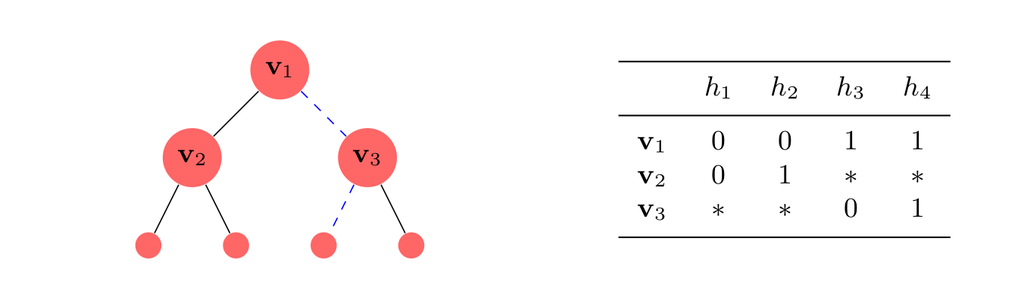

Fig. 21.1 de [SSBD]

## Dimensão de Littlestone

Uma árvore de estratégia com vértices $(v_1, \dotsc, v_{2^{T + 1}-1})$ é **fragmentada** por $\cH$ se **para todo** $y \in \{0,1\}^T$ , definindo $x_1 = v_1$ e
$$x_{t+1} = \DESC(x_{i}, y_i) \quad \text{para todo}~t \in [T-1],$$
existe $h \in \cH$ tal que $h(x_t) = y_t$ para todo $t \in [T]$.

Assim como em aprendizado estatístico, a ideia de **fragmentação** nos leva a uma noção de **dimensão de $\cH$**

A **dimensão de Littlestone** $\LDim(\cH)$ de $\cH$ o maior $T \in \bN$ tal que existe uma árvore de estratégia de profundiade $T$ fragmentada por $\cH$

Nenhum algoritmo pro jogador contra um adversário realizado por $\cH$ pode garantir menos que $\LDim(\cH)$ erros.

## Exemplo - $\cH$ finito

## Exemplo - Thresholds

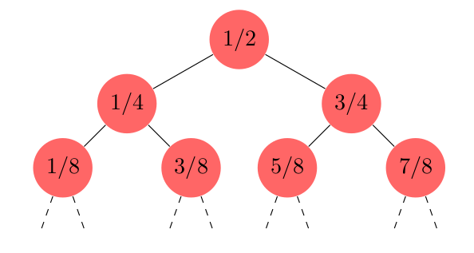

Ex. 21.4 de [SSBD]